# PA1_template.Rmd by John Broberg

```r
# Clear Variables
rm(list = ls())

# Attach packages
library(plyr)
library(dplyr)
library(lubridate)
```

```r
library(ggplot2)
```

# Loading and preprocessing the data

### Show any code that is needed to

1. Load the data (i.e. read.csv())

```r
# Create data folder to store files
if(!file.exists("./data")){dir.create("./data")}

# Download raw data
fileURL <- "https://d396qusza40orc.cloudfront.net/repdata%2Fdata%2Factivity.zip"
download.file(fileURL, destfile="./data/activity.zip")

# Unzip file
unzip(zipfile="./data/activity.zip", exdir="./data")

# Read in file(s)
activity <- read.csv("./data/activity.csv")

# Review data
dim(activity)
```

```
## [1] 17568     3
```

```r
head(activity)
```

```
##   steps       date interval
## 1    NA 2012-10-01        0
## 2    NA 2012-10-01        5
## 3    NA 2012-10-01       10
## 4    NA 2012-10-01       15
## 5    NA 2012-10-01       20
## 6    NA 2012-10-01       25
```

```r
tail(activity)
```

```
##       steps       date interval
## 17563    NA 2012-11-30     2330
## 17564    NA 2012-11-30     2335
## 17565    NA 2012-11-30     2340
## 17566    NA 2012-11-30     2345
## 17567    NA 2012-11-30     2350
## 17568    NA 2012-11-30     2355
```

```r
summary(activity)
```

```
##      steps                date          interval
##  Min.   :  0.00   2012-10-01:  288   Min.   :   0.0
##  1st Qu.:  0.00   2012-10-02:  288   1st Qu.: 588.8
##  Median :  0.00   2012-10-03:  288   Median :1177.5
##  Mean   : 37.38   2012-10-04:  288   Mean   :1177.5
##  3rd Qu.: 12.00   2012-10-05:  288   3rd Qu.:1766.2
##  Max.   :806.00   2012-10-06:  288   Max.   :2355.0
##  NA's   :2304     (Other)   :15840
```

```r
names(activity)
```

```
## [1] "steps"    "date"     "interval"
```

```r
str(activity)
```

```
## 'data.frame':    17568 obs. of  3 variables:
##  $ steps   : int  NA NA NA NA NA NA NA NA NA NA ...
##  $ date    : Factor w/ 61 levels "2012-10-01","2012-10-02",..: 1 1 1 1 1 1 1 1 1 1 ...
##  $ interval: int  0 5 10 15 20 25 30 35 40 45 ...
```

2. Process/transform the data (if necessary) into a format suitable for your analysis

```r
# Total steps by date, remove NA
total.steps <- tapply(activity$steps, activity$date, FUN = sum, na.rm = TRUE)

# Format date
activity$date <- ymd(activity$date)
```

# What is mean total number of steps taken per day?

```r
mean(total.steps)
```

```
## [1] 9354.23
```

*For this part of the assignment, you can ignore the missing values in the dataset.*

1. Calculate the total number of steps taken per day

```r
stepsPerDay <- activity %>%
    filter(!is.na(steps)) %>%
    group_by(date) %>%
    summarize(steps = sum(steps)) %>%
    print
```

```
## # A tibble: 53 × 2
##          date steps
##        <date> <int>
## 1  2012-10-02   126
## 2  2012-10-03 11352
## 3  2012-10-04 12116
## 4  2012-10-05 13294
## 5  2012-10-06 15420
## 6  2012-10-07 11015
## 7  2012-10-09 12811
## 8  2012-10-10  9900
## 9  2012-10-11 10304
## 10 2012-10-12 17382
## # ... with 43 more rows
```

2. Make a histogram of the total number of steps taken each day

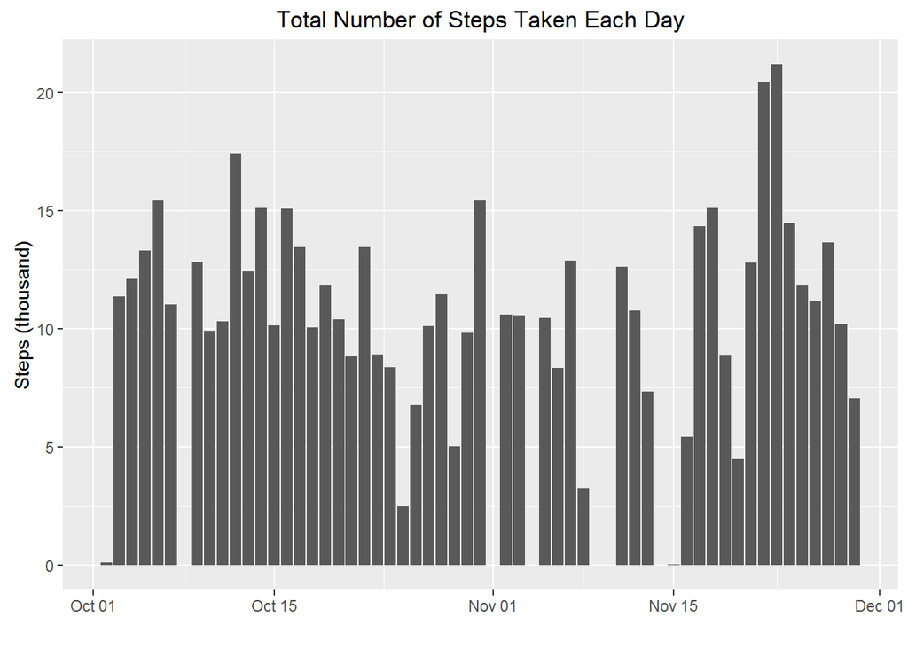

```r
plot1 <- ggplot(stepsPerDay, aes(date, steps/1000))
plot1 + geom_bar(stat="identity") +
    labs(x = "", y = "Steps (thousand)") +
    labs(title= "Total Number of Steps Taken Each Day")
```

3. Calculate and report the mean and median of the total number of steps taken per day

```r
mean(total.steps)
```

```
## [1] 9354.23
```

```r
median(total.steps)
```

```
## [1] 10395
```

# What is the average daily activity pattern?

```r
stepsPerInterval <- activity %>%
    filter(!is.na(steps)) %>%
    group_by(interval) %>%
    summarize(steps = mean(steps)) %>%
    print
```

```
## # A tibble: 288 × 2
##    interval     steps
##       <int>     <dbl>
## 1         0 1.7169811
## 2         5 0.3396226
## 3        10 0.1320755
## 4        15 0.1509434
## 5        20 0.0754717
## 6        25 2.0943396
## 7        30 0.5283019
## 8        35 0.8679245
## 9        40 0.0000000
## 10       45 1.4716981
## # ... with 278 more rows
```

1. Make a time series plot (i.e. type = “l”) of the 5-minute interval (x-axis) and the average number of steps taken, averaged across all days (y-axis)

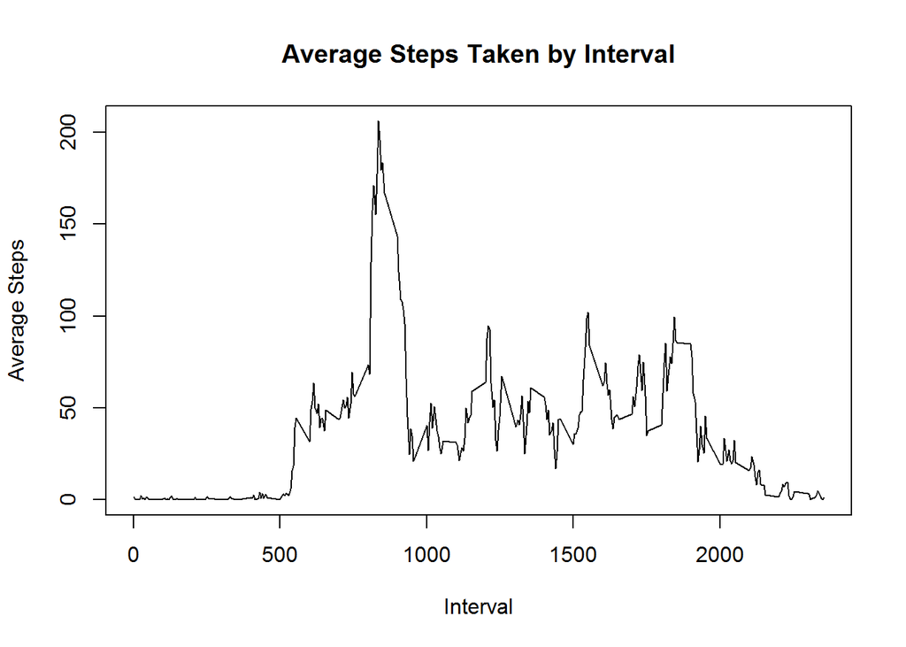

```r
plot(stepsPerInterval, type = "l", xlab = "Interval", ylab = "Average Steps")
title(main = "Average Steps Taken by Interval")
```

2. Which 5-minute interval, on average across all the days in the dataset, contains the maximum number of steps?

```r
stepsPerInterval[which.max(stepsPerInterval$steps),]$interval
```

```
## [1] 835
```

# Imputing missing values

*Note that there are a number of days/intervals where there are missing values (coded as NA). The presence of missing days may introduce bias into some calculations or summaries of the data.*

1. Calculate and report the total number of missing values in the dataset (i.e. the total number of rows with NAs)

```r
# Total number of missing values (i.e. NA) in activity
sum(is.na(activity))
```

```
## [1] 2304
```

2. Devise a strategy for filling in all of the missing values in the dataset. The strategy does not need to be sophisticated. For example, you could use the mean/median for that day, or the mean for that 5-minute interval, etc.

3. Create a new dataset that is equal to the original dataset but with the missing data filled in.

```r
# Create dataset with NA changed to mean of all steps
activityNAtoMean <- activity %>%
    group_by(interval) %>%
    mutate(steps = ifelse(is.na(steps), mean(steps, na.rm = TRUE), steps))
summary(activityNAtoMean)
```

```
##      steps             date               interval
##  Min.   :  0.00   Min.   :2012-10-01   Min.   :   0.0
##  1st Qu.:  0.00   1st Qu.:2012-10-16   1st Qu.: 588.8
##  Median :  0.00   Median :2012-10-31   Median :1177.5
##  Mean   : 37.38   Mean   :2012-10-31   Mean   :1177.5
##  3rd Qu.: 27.00   3rd Qu.:2012-11-15   3rd Qu.:1766.2
##  Max.   :806.00   Max.   :2012-11-30   Max.   :2355.0
```

4. Make a histogram of the total number of steps taken each day

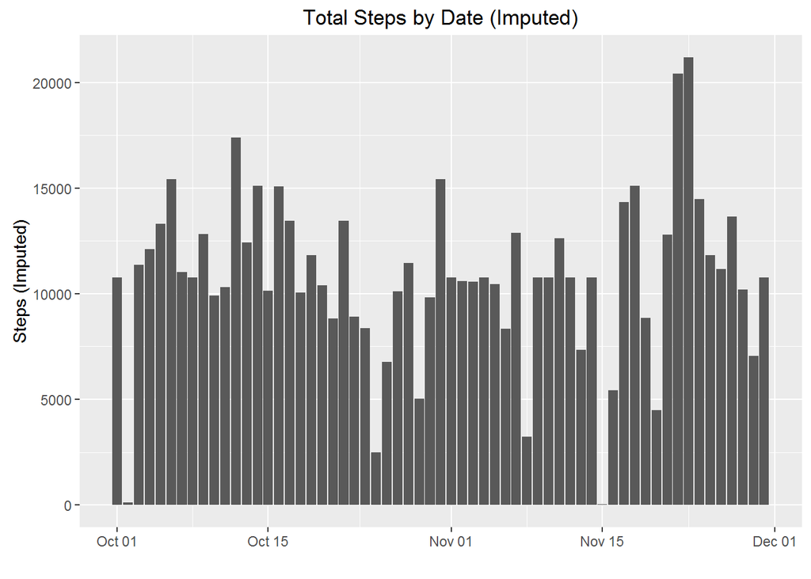

```r
activityNAtoMean.steps <- activityNAtoMean %>%
    group_by(date) %>%
    summarize(steps = sum(steps))

ggplot(activityNAtoMean.steps, aes(x=date, y=steps)) +
    geom_bar(stat = "identity") +
    labs(x = "", y = "Steps (Imputed)", title = "Total Steps by Date (Imputed)")
```

- …and Calculate and report the mean and median total number of steps taken per day.

```r
imputed.steps <- tapply(activityNAtoMean$steps, activityNAtoMean$date, FUN = sum, na.rm = TRUE)
activityNAtoMean$date <- ymd(activityNAtoMean$date)
mean(imputed.steps)
```

```
## [1] 10766.19
```

```r
median(imputed.steps)
```

```
## [1] 10766.19
```

- Do these values differ from the estimates from the first part of the assignment?

```r
if(mean(total.steps)==mean(imputed.steps)) {
    "No, mean values are equal."
}   else {
    "Yes, mean values differ."
}
```

```
## [1] "Yes, mean values differ."
```

```r
if(median(total.steps)==median(imputed.steps)) {
    "No, median values are equal."
}   else {
    "Yes, median values differ."
}
```

```
## [1] "Yes, median values differ."
```

- What is the impact of imputing missing data on the estimates of the total daily number of steps?

Imputing the missing data impacted the estimates by the following differences:

```r
summary(imputed.steps) - summary(total.steps)
```

```
##    Min. 1st Qu.  Median    Mean 3rd Qu.    Max.
##      41    3041     370    1416       0       0
```

# Are there differences in activity patterns between weekdays and weekends?

*For this part the weekdays() function may be of some help here. Use the dataset with the filled-in missing values for this part.*

1. Create a new factor variable in the dataset with two levels - “weekday” and “weekend” indicating whether a given date is a weekday or weekend day.

```r
weekdayWeekend <- function(date){
    if(weekdays(as.Date(date)) %in% c("Saturday", "Sunday")) {
        "weekend"
    }else {
        "weekday"
    }
}

activity$daytype <- as.factor(sapply(activity$date, weekdayWeekend))
summary(activity)
```

```
##      steps             date               interval         daytype
##  Min.   :  0.00   Min.   :2012-10-01   Min.   :   0.0   weekday:12960
##  1st Qu.:  0.00   1st Qu.:2012-10-16   1st Qu.: 588.8   weekend: 4608
##  Median :  0.00   Median :2012-10-31   Median :1177.5
##  Mean   : 37.38   Mean   :2012-10-31   Mean   :1177.5
##  3rd Qu.: 12.00   3rd Qu.:2012-11-15   3rd Qu.:1766.2
##  Max.   :806.00   Max.   :2012-11-30   Max.   :2355.0
##  NA's   :2304
```

2. Make a panel plot containing a time series plot (i.e. type = “l”) of the 5-minute interval (x-axis) and the average number of steps taken, averaged across all weekday days or weekend days (y-axis). See the README file in the GitHub repository to see an example of what this plot should look like using simulated data.

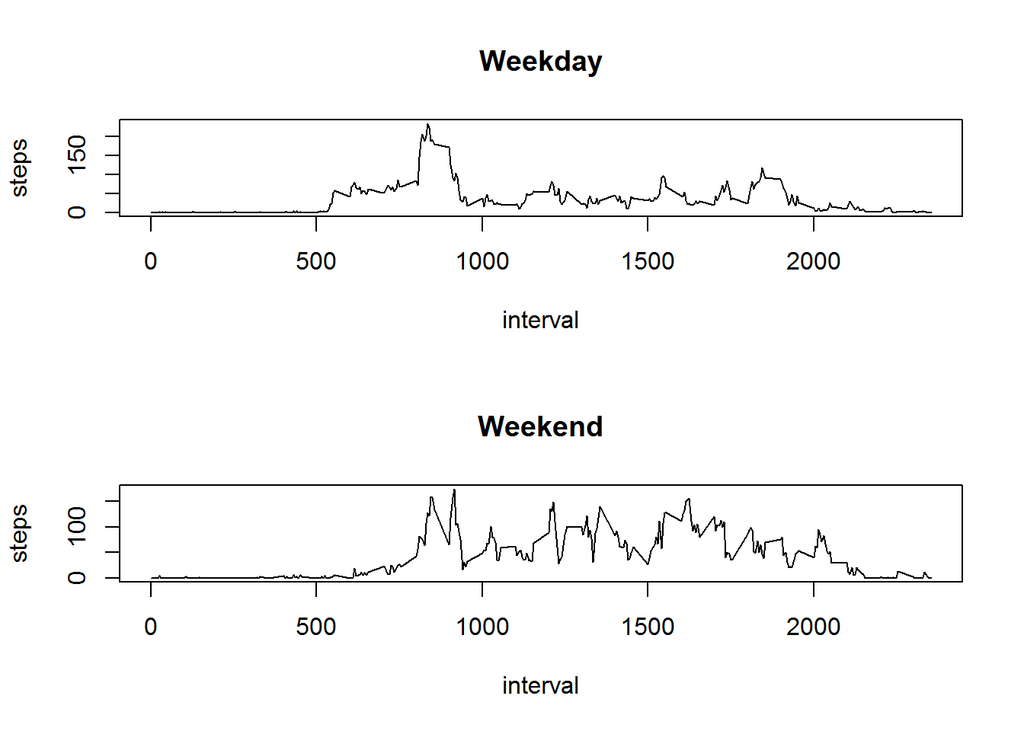

```r
par(mfrow = c(2,1))

stepsWeekday <- aggregate(steps ~ interval, data = activity,
    subset = activity$daytype == "weekday", FUN = mean)
stepsWeekend <- aggregate(steps ~ interval, data = activity,
    subset = activity$daytype == "weekend", FUN = mean)

plot(stepsWeekday, type = "l", main = "Weekday")
plot(stepsWeekend, type = "l", main = "Weekend")
```